# Exercise Set G

Mitchell Toomey

April 2, 2021

```r
library(here)
library(tidyverse)
library(dplyr)
library(hrbrthemes)
library(MASS)
library(lattice)

college_data <- read_csv(here("Data", "College Study Data (Clean).csv"))
johnson_elem <- read_csv(here("Data", "Johnson Elementary ELA Project_Cleaned.csv"))
college_data
```

| X1 | id | gender | class | gpa | scale1 | scale2 |
| --- | --- | --- | --- | --- | --- | --- |
| 1 | 1 | female | freshman | 3.08 | 2 | 9 |
| 2 | 2 | female | junior | 2.89 | 2 | 2 |
| 3 | 3 | female | junior | 3.17 | 4 | 9 |
| 4 | 4 | male | senior | 2.10 | 3 | 2 |
| 5 | 5 | female | junior | 2.66 | 4 | 8 |
| 6 | 6 | male | junior | 3.01 | 2 | 1 |
| 7 | 7 | female | junior | 2.42 | 3 | 3 |
| 8 | 8 | female | sophomore | 2.45 | 1 | 7 |
| 9 | 9 | female | senior | 2.24 | 2 | 6 |
| 10 | 10 | female | junior | 2.33 | 1 | 4 |

[output cut: 990 more lines]

1. Use the College Study Data to calculate the means of the two scales by gender, by class, and by a combination of gender and class.

```r
# means grouped by gender

college_data %>%
  group_by(gender) %>%
  summarize(scale1_mean = mean(scale1, na.rm = TRUE),
            scale2_mean = mean(scale2, na.rm = TRUE))
```

|  | gender | scale1_mean | scale2_mean |
| --- | --- | --- | --- |
| 1 | female | 2.773279 | 5.122689 |
| 2 | male | 2.777854 | 5.100616 |

```r
# means grouped by class

college_data %>%
  group_by(class) %>%
  summarize(scale1_mean = mean(scale1, na.rm = TRUE),
            scale2_mean = mean(scale2, na.rm = TRUE))
```

|  | class | scale1_mean | scale2_mean |
| --- | --- | --- | --- |
| 1 | freshman | 2.807604 | 5.122225 |
| 2 | junior | 2.768814 | 5.076155 |
| 3 | senior | 2.738553 | 5.152911 |
| 4 | sophomore | 2.783258 | 5.095175 |

```r
# means groups by class x gender

college_data %>%
  group_by(class, gender) %>%
  summarize(scale1_mean = mean(scale1, na.rm = TRUE),
            scale2_mean = mean(scale2, na.rm = TRUE))
```

| class | gender | scale1_mean | scale2_mean |
| --- | --- | --- | --- |
| freshman | female | 2.810318 | 5.121939 |
| freshman | male | 2.805000 | 5.122500 |
| junior | female | 2.750576 | 5.055908 |
| junior | male | 2.786682 | 5.095991 |
| senior | female | 2.715297 | 5.125204 |
| senior | male | 2.763668 | 5.182834 |
| sophomore | female | 2.812304 | 5.181439 |
| sophomore | male | 2.752864 | 5.004910 |

2. Construct side-by-side boxplots for the GPA for freshmen and seniors.

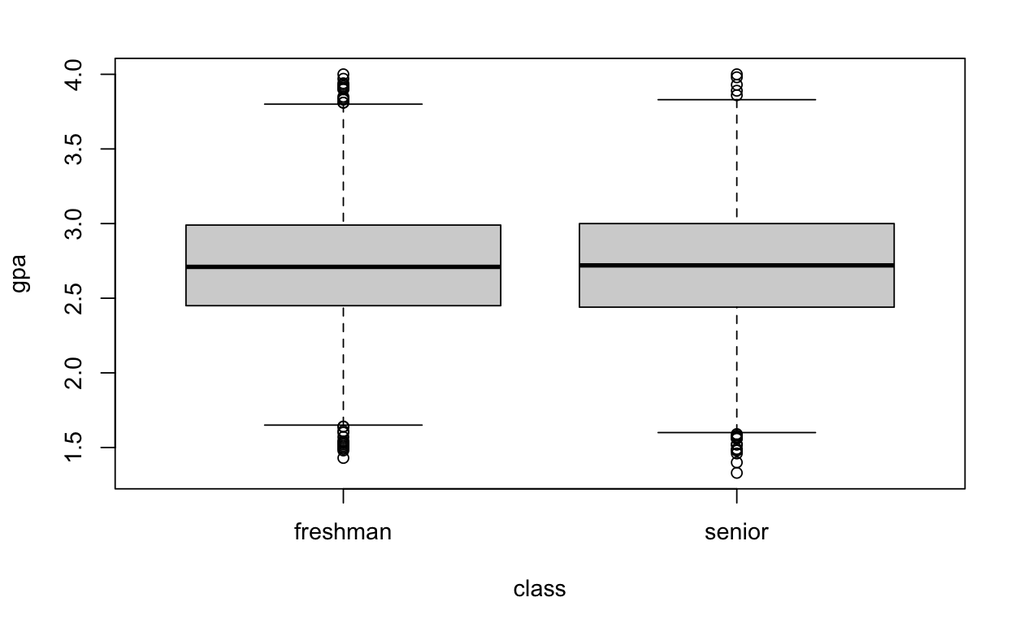

```r
# subset class by freshman and senior

boxplot(gpa ~ class, data = college_data,
        subset = class %in% c("freshman", "senior"))
```

```r
NA
```

3. Write a script to import and tidy the Johnson Elementary Project Data. You have done this before, but now use a single chain of pipes and make certain the data are formally tidy. (20 points)

```r
library(readxl)

johnson_elem <- read_excel(here("Data", "Johnson Elementary ELA Project.xlsx"),
                           skip = 3)
```

```
* `` -> ...1
```

```r
johnson_elem <- rename(johnson_elem, "Room Number" = "...1")

# Fill names of room numbers, separate tardies and absences,
# put quarters into a single quarter variable using a single chain of pipes

johnson_elem <- johnson_elem %>%
  fill("Room Number") %>%
  separate("Tardies; Absences", into = c("Tardies", "Absences")) %>%
  gather("1st Quarter", "2nd Quarter", "3rd Quarter", "4th Quarter",
         key = "Quarter",
         value = "Score")

# check for any problems

problems(johnson_elem)
```

| row | col | expected | actual |
| --- | --- | --- | --- |

```r
# making sure it looks okay

johnson_elem
```

| Room Number | Student ID | Tardies | Absences | Quarter | Score |
| --- | --- | --- | --- | --- | --- |
| Room 105 | NA | NA | NA | 1st Quarter | NA |
| Room 105 | 400 | 14 | 20 | 1st Quarter | 15 |
| Room 105 | 461 | 14 | 0 | 1st Quarter | 14 |
| Room 105 | 195 | 15 | 20 | 1st Quarter | 11 |
| Room 105 | 449 | 12 | 15 | 1st Quarter | 6 |
| Room 105 | 454 | 16 | 4 | 1st Quarter | 5 |
| Room 105 | 142 | 5 | 8 | 1st Quarter | 18 |
| Room 105 | 357 | 4 | 1 | 1st Quarter | 14 |
| Room 105 | 197 | 5 | 1 | 1st Quarter | 14 |
| Room 105 | 464 | 5 | 13 | 1st Quarter | 16 |

[output cut: 858 more lines]

```r
# writing it to a new file

write_csv(johnson_elem, here("Data", "Johnson Elementary ELA Project_Cleaned2.csv"))
```

4. Write a script to provide summary statistics for the number of tardies and absences for each room.

```r
johnson_elem <- read_csv(here("Data", "Johnson Elementary ELA Project_Cleaned2.csv"))
johnson_elem %>%
  group_by(`Room Number`) %>%
  summarize(mean(Tardies, na.rm = TRUE),
            sd(Tardies, na.rm = TRUE),
            min(Tardies, na.rm = TRUE),
            max(Tardies, na.rm=TRUE))
```

|  | Room Number | mean(Tardies, na.rm = TRUE) | sd(Tardies, na.rm = TRUE) | min(Tardies, na.rm = TRUE) | max(Tardies, na.rm = TRUE) |
| --- | --- | --- | --- | --- | --- |
| 1 | Room 105 | 10.750000 | 4.291587 | 3 | 16 |
| 2 | Room 117 | 9.500000 | 3.880396 | 3 | 16 |
| 3 | Room 118 | 7.304348 | 4.911836 | 0 | 16 |
| 4 | Room 123 | 7.565217 | 4.562880 | 0 | 16 |
| 5 | Room 125 | 8.954545 | 4.239684 | 1 | 16 |
| 6 | Room 129 | 8.590909 | 4.625358 | 0 | 16 |
| 7 | Room 132 | 7.142857 | 4.526402 | 1 | 16 |
| 8 | Room 137 | 9.210526 | 4.948578 | 0 | 16 |
| 9 | Room 140 | 7.761905 | 4.778514 | 0 | 15 |
| 10 | Room 147 | 6.238095 | 5.053018 | 0 | 16 |

```r
johnson_elem %>%
  group_by(`Room Number`) %>%
  summarize(mean(Absences, na.rm = TRUE),
            sd(Absences, na.rm = TRUE),
            min(Absences, na.rm = TRUE),
            max(Absences, na.rm=TRUE))
```

|  | Room Number | mean(Absences, na.rm = TRUE) | sd(Absences, na.rm = TRUE) | min(Absences, na.rm = TRUE) | max(Absences, na.rm = TRUE) |
| --- | --- | --- | --- | --- | --- |
| 1 | Room 105 | 10.950000 | 7.404925 | 0 | 23 |
| 2 | Room 117 | 8.272727 | 6.815680 | 0 | 23 |
| 3 | Room 118 | 13.434783 | 6.239372 | 2 | 23 |
| 4 | Room 123 | 13.478261 | 7.352174 | 0 | 23 |
| 5 | Room 125 | 10.318182 | 7.042638 | 0 | 23 |
| 6 | Room 129 | 9.818182 | 5.861516 | 1 | 21 |
| 7 | Room 132 | 10.428571 | 6.635599 | 0 | 22 |
| 8 | Room 137 | 10.473684 | 6.485828 | 0 | 21 |
| 9 | Room 140 | 12.714286 | 6.438909 | 3 | 23 |
| 10 | Room 147 | 10.904762 | 7.166890 | 0 | 23 |

```r
NA
```

5. Write a script to show the frequency of missing data points for each quarter by room.

```r
johnson_elem %>%
  group_by(`Room Number`) %>%
  summarize(count = sum(is.na(johnson_elem$Quarter)))
```

|  | Room Number | count |
| --- | --- | --- |
| 1 | Room 105 | 0 |
| 2 | Room 117 | 0 |
| 3 | Room 118 | 0 |
| 4 | Room 123 | 0 |
| 5 | Room 125 | 0 |
| 6 | Room 129 | 0 |
| 7 | Room 132 | 0 |
| 8 | Room 137 | 0 |
| 9 | Room 140 | 0 |
| 10 | Room 147 | 0 |

```r
NA
```

6. Construct a graph that illustrates the median rating trends across the four quarters for the fifth- grade classes. (20 points)

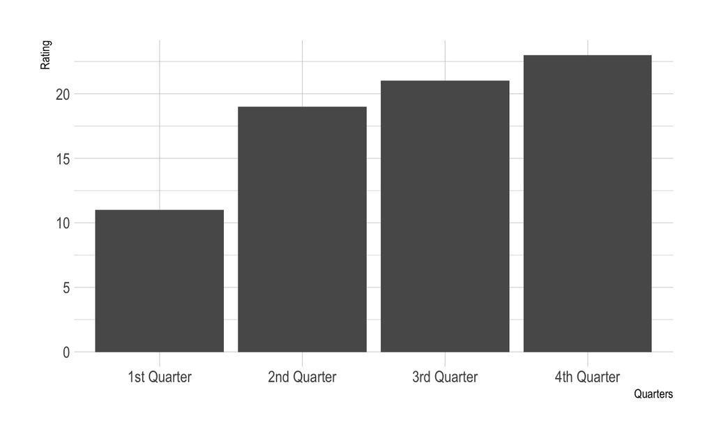

```r
johnson_elem %>%
  group_by(Quarter) %>%
  summarize(rating = median(Score, na.rm = TRUE)) %>%
  ggplot(aes(x=Quarter, y=rating)) +
  geom_bar(stat = "identity") +
  theme_ipsum() +
  labs(x="Quarters", y="Rating")
```

7. Use the NYC flights data to construct a graph that compares carriers in terms of the proportion of 2013 flights that arrived on time when traveling from New York City to Atlanta. Your graph should include a title and easy-to-read labels, including the names of airlines rather than airline codes. You can find airline names in the Airlines Data. (40 points)

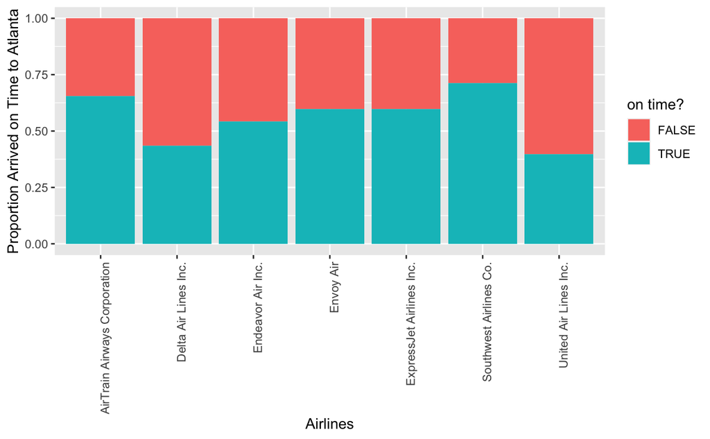